# The Pronunciation of the Word “Māori”

30/08/2023

# 1 Overview

This document presents the analysis steps and results for ‘The Pronunciation of the Word “Māori”’.

The following sections cover:

1. loading data and libraries,
2. initial data examination,
3. the binary flap model,
4. the binary diphthong model, and
5. the diphthong ratio model.

# 2 Load data and libraries

We load the required libraries.

```r
# Tidyverse contains plotting and data manipulation functions used throughout
# this markdown file.
library(tidyverse)
library(gt) # gt provides additional table output options.

# Linear mixed modelling
library(lme4)
library(effects)
library(emmeans)
```

We read in the data and create a binary variable indicating whether a token is a diphthong or not. All diphthong tokens have a ‘ratio’ of /a:/ to /o/, so we can create a binary variable by indicating ‘not diphthong’ for every token without a ratio.

```r
merged_data <- read_rds('merged_data.rds')

merged_data <- merged_data |>
  # Store flap info as a factor for modelling.
  mutate(
    Flap = as.factor(Flap),
    generation = factor(
      merged_data$generation, levels=c("Hist", "TK", "Pres", "L1", "L2")
    ),
    Ratio = as.numeric(str_replace_all(Ratio, ",", "\\."))
  )

filtered_data <- merged_data |>
  # Remove Tūhoe speakers (for models with gender)
  filter(
    !generation == "TK"
  ) |>
  # create diphthong variable. Ngāi Tūhoe speakers were not included in the
  # diphthong models as gender was found to be significant.
  mutate(
    diphthong = as.factor(if_else(is.na(Ratio), 'n', 'y'))
  )
```

# 3 Data exploration

What variables do we have?

```r
column_descriptions_initial <- c(
  "Search term used in LaBB-CAT",
  "Number of result",
  "Name of transcript",
  "Speaker name",
  "Speaker gender (binary)",
  "Language being spoken",
  "Speaker year of birth",
  "Speaker region",
  "Start time of transcript line (s)",
  "End time of transcript line (s)",
  "LaBB-CAT token identifier",
  "URL to access token in LaBB-CAT",
  "Previous segment",
  "Word (with whitespace removed)",
  "Following segment",
  "Word from LaBB-CAT text layer",
  "Onset of word (s)",
  "Offset of word (s)",
  "Word without punctuation",
  "Binary flap variable (y/n)",
  "Length of /a:/",
  "Length of /o/",
  "Ratio of /a:/ to /o/",
  "Comments concerning token",
  "MAONZE group identifier",
  "Speaker code without language identifier",
  "MAONZE generation category",
  "Binary diphthong variable (y/n)"
)

data_table <- tibble(
  `Variable Name` = names(filtered_data),
  Type = reframe(filtered_data, across(everything(), class)) |> as_vector(),
  Description = column_descriptions_initial
)

data_table <- data_table %>%
  gt() %>%
  tab_header(
    title = "Variables in the data set"
  )

data_table
```

Variables in the data set

| Variable Name | Type | Description |
| --- | --- | --- |
| SearchName | character | Search term used in LaBB-CAT |
| Number | numeric | Number of result |
| Transcript | character | Name of transcript |
| Speaker | character | Speaker name |
| participant_gender | character | Speaker gender (binary) |
| participant_language | character | Language being spoken |
| participant_year_of_birth | numeric | Speaker year of birth |
| participant_region | character | Speaker region |
| Line | numeric | Start time of transcript line (s) |
| LineEnd | numeric | End time of transcript line (s) |
| MatchId | character | LaBB-CAT token identifier |
| URL | character | URL to access token in LaBB-CAT |
| Before Match | character | Previous segment |
| Text | character | Word (with whitespace removed) |
| After Match | character | Following segment |
| Target word | character | Word from LaBB-CAT text layer |
| Target word start | numeric | Onset of word (s) |
| Target word end | numeric | Offset of word (s) |
| Target orthography | character | Word without punctuation |
| Flap | factor | Binary flap variable (y/n) |
| a: length | character | Length of /a:/ |
| o length | character | Length of /o/ |
| Ratio | numeric | Ratio of /a:/ to /o/ |
| Comments | character | Comments concerning token |
| group | factor | MAONZE group identifier |
| CleanSpeaker | character | Speaker code without language identifier |
| generation | factor | MAONZE generation category |
| diphthong | factor | Binary diphthong variable (y/n) |

We check for balanced data across our classes.

```r
table(merged_data$participant_gender, merged_data$participant_language)
```

```
##
##     English Maori
##   F     199   228
##   M     257   242
```

```r
table(
  merged_data$participant_gender,
  merged_data$participant_language,
  merged_data$generation
)
```

```
## , ,  = Hist
##
##
##     English Maori
##   F      22    37
##   M      39    22
##
## , ,  = TK
##
##
##     English Maori
##   F       0     0
##   M      46    43
##
## , ,  = Pres
##
##
##     English Maori
##   F      85    84
##   M      75    90
##
## , ,  = L1
##
##
##     English Maori
##   F      46    60
##   M      51    43
##
## , ,  = L2
##
##
##     English Maori
##   F      46    47
##   M      46    44
```

Note the absence of female speakers in the Tūhoe generation. As noted above, we exclude Tūhoe data from models with gender in the predictor variables.

What does the raw data look like?

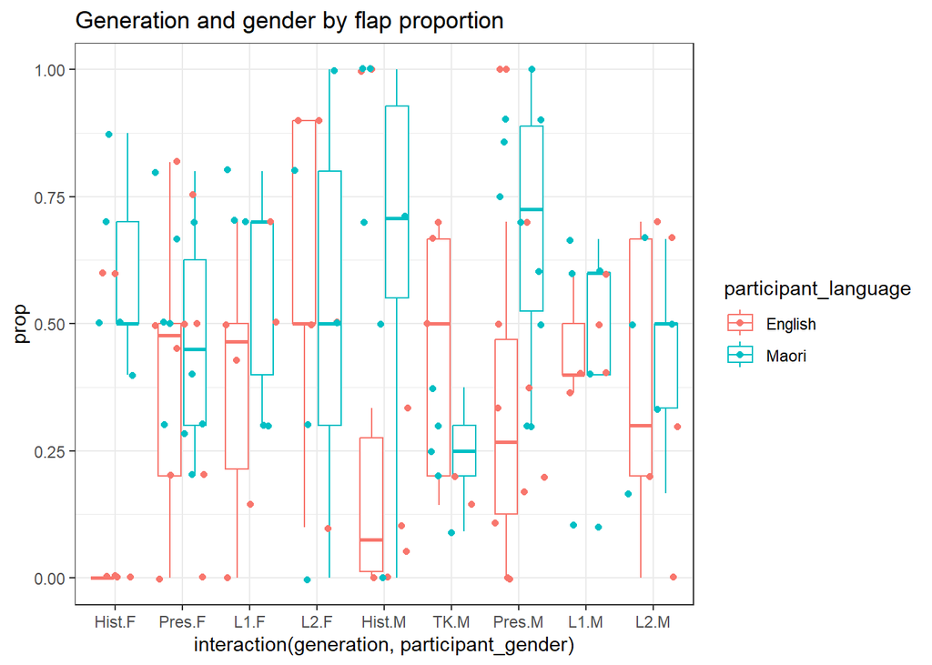

```r
merged_data |>
  group_by(CleanSpeaker, generation, participant_gender, participant_language) |>
  summarise(
    total = n(),
    flap = sum(Flap == "y"),
    prop = flap/total
  ) |>
  ggplot(
    aes(
      x = interaction(generation, participant_gender),
      y = prop,
      colour = participant_language,
    )
  ) +
  geom_boxplot() +
  geom_jitter() +
  labs(
    title = "Generation and gender by flap proportion",
  ) +
  theme_bw()
```

The results for `Hist.F` look extreme. We double checked these values and found no reason to doubt them.

We can also consider the variation between individual speakers in flap proportion.

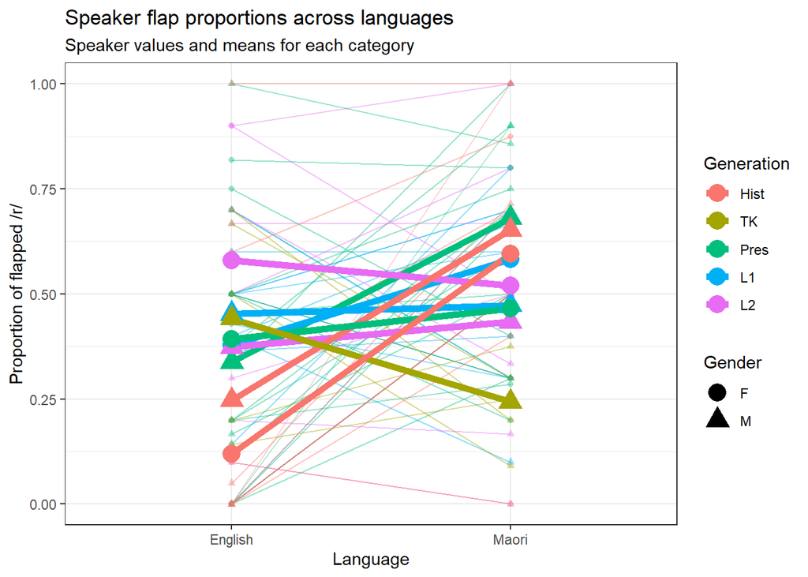

Figure 3.1: Proportion flaps for speakers across languages. Thick lines are means for each category of speaker.

```r
speaker_data <- merged_data |>
  group_by(CleanSpeaker, generation, participant_gender, participant_language) |>
  summarise(
    total = n(),
    flap = sum(Flap == "y"),
    prop = flap/total
  )

mean_props <- speaker_data |>
  ungroup() |>
  group_by(generation, participant_gender, participant_language) |>
  mutate(
    prop = mean(prop)
  )

speaker_data |>
  ggplot(
    aes(
      x = participant_language,
      y = prop,
      group = CleanSpeaker,
      colour = generation,
      shape = participant_gender
    )
  ) +
  geom_line(alpha = 0.4) +
  geom_point(alpha = 0.4) +
  geom_line(
    data = mean_props,
    linewidth = 2
  ) +
  geom_point(
    data = mean_props,
    size = 5
  ) +
  labs(
    title = "Speaker flap proportions across languages",
    subtitle = "Speaker values and means for each category",
    colour = "Generation",
    shape = "Gender",
    x = "Language",
    y = "Proportion of flapped /r/"
  ) +
  theme_bw()
```

Figure 3.1 already indicates some differences across categories.

What about for the diphthong variable?

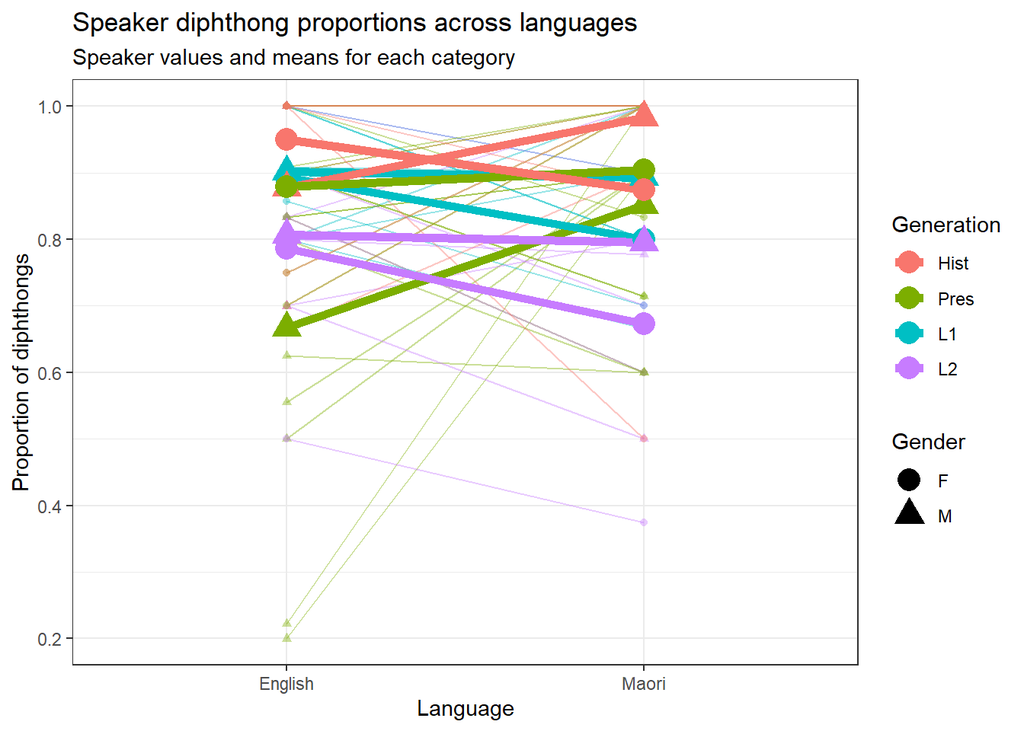

Figure 3.2: Proportion dipthongs for speakers across languages. Thick lines are means for each category of speaker.

```r
speaker_data <- filtered_data |>
  group_by(CleanSpeaker, generation, participant_gender, participant_language) |>
  summarise(
    total = n(),
    flap = sum(diphthong == "y"),
    prop = flap/total
  )

mean_props <- speaker_data |>
  ungroup() |>
  group_by(generation, participant_gender, participant_language) |>
  mutate(
    prop = mean(prop)
  )

speaker_data |>
  ggplot(
    aes(
      x = participant_language,
      y = prop,
      group = CleanSpeaker,
      colour = generation,
      shape = participant_gender
    )
  ) +
  geom_line(alpha = 0.4) +
  geom_point(alpha = 0.4) +
  geom_line(
    data = mean_props,
    linewidth = 2
  ) +
  geom_point(
    data = mean_props,
    size = 5
  ) +
  labs(
    title = "Speaker diphthong proportions across languages",
    subtitle = "Speaker values and means for each category",
    colour = "Generation",
    shape = "Gender",
    x = "Language",
    y = "Proportion of diphthongs"
  ) +
  theme_bw()
```

In Figure 3.2, Diphthong rates seem high across the board with the exception of two male present day kaumātua while speaking English.

Finally, what does the ratio variable look like?

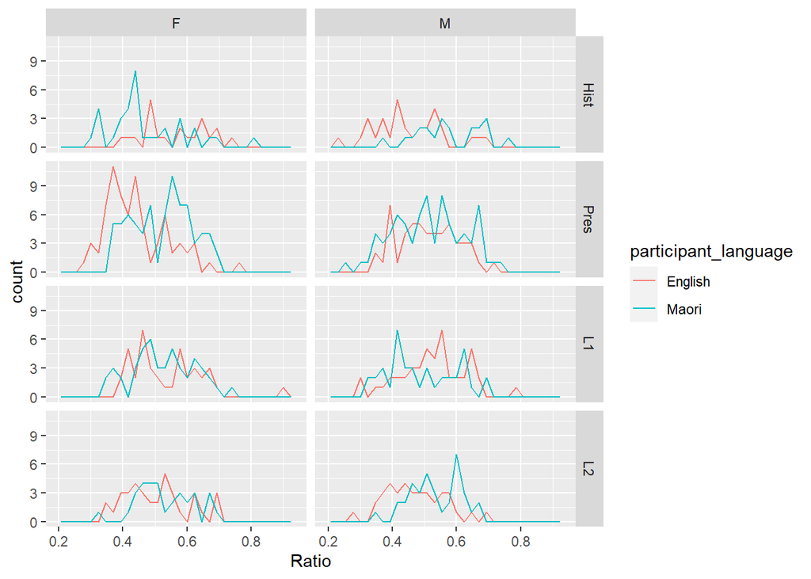

```r
filtered_data |>
  ggplot(
    aes(
      x = Ratio,
      colour = participant_language
    )
  ) +
  geom_freqpoly() +
  facet_grid(rows = vars(generation), cols = vars(participant_gender))
```

There are no obvious patterns in the distributions of dipthong ratio. All values look sensible.

# 4 Flap model

## 4.1 Without Tūhoe speakers

For all models, we start with a maximal structure with three way interactions for language, gender, and generation, along with random intercepts and slopes on language for each speaker. If none of the coefficients for a predictor are significant at the 0.05 level, we remove the predictor from subsequent models.

The following code fits the first model.

```r
Flapmodel0 <- glmer(
  # Dependent variable
  Flap ~
    # Independent variables / Main effects / predictors
    generation * participant_gender * participant_language +
    # Random effects
    (1 + participant_language|CleanSpeaker),
  # Family binomial because it's a 'yes or no' modelling problem.
  family = "binomial",
  # Tell it the dataset.
  data = filtered_data,
  # Some magic words to give the model additional time to 'converge'.
  glmerControl(optimizer = "nlminbwrap", optCtrl = list(maxfun = 1e7)),
  # Optimizer chosen using 'allFit' function
)
```

Let’s have a look at this model. First the summary.

```r
summary(Flapmodel0)
```

```
## Generalized linear mixed model fit by maximum likelihood (Laplace
##   Approximation) [glmerMod]
##  Family: binomial  ( logit )
## Formula: Flap ~ generation * participant_gender * participant_language +
##     (1 + participant_language | CleanSpeaker)
##    Data: filtered_data
## Control: glmerControl(optimizer = "nlminbwrap", optCtrl = list(maxfun = 1e+07))
##
##      AIC      BIC   logLik deviance df.resid
##   1084.0   1173.8   -523.0   1046.0      818
##
## Scaled residuals:
##     Min      1Q  Median      3Q     Max
## -2.2870 -0.8159 -0.2788  0.8488  3.5868
##
## Random effects:
##  Groups       Name                      Variance Std.Dev. Corr
##  CleanSpeaker (Intercept)               1.136    1.066
##               participant_languageMaori 1.116    1.057    -0.77
## Number of obs: 837, groups:  CleanSpeaker, 52
##
## Fixed effects:
##                                                              Estimate
## (Intercept)                                                  -2.32058
## generationPres                                                1.79999
## generationL1                                                  1.96369
## generationL2                                                  2.73850
## participant_genderM                                           0.21409
## participant_languageMaori                                     2.83351
## generationPres:participant_genderM                           -0.37951
## generationL1:participant_genderM                             -0.06562
## generationL2:participant_genderM                             -1.34638
## generationPres:participant_languageMaori                     -2.47584
## generationL1:participant_languageMaori                       -2.11027
## generationL2:participant_languageMaori                       -3.12689
## participant_genderM:participant_languageMaori                 0.06135
## generationPres:participant_genderM:participant_languageMaori  1.05016
## generationL1:participant_genderM:participant_languageMaori   -0.80831
## generationL2:participant_genderM:participant_languageMaori    0.70812
##                                                              Std. Error z value
```

[output cut: 20 more lines]

```
## generationL2                                                  0.01295 *
## participant_genderM                                           0.85835
## participant_languageMaori                                     0.00413 **
## generationPres:participant_genderM                            0.77921
## generationL1:participant_genderM                              0.96344
## generationL2:participant_genderM                              0.36098
## generationPres:participant_languageMaori                      0.02383 *
## generationL1:participant_languageMaori                        0.06865 .
## generationL2:participant_languageMaori                        0.00928 **
## participant_genderM:participant_languageMaori                 0.96381
## generationPres:participant_genderM:participant_languageMaori  0.49181
## generationL1:participant_genderM:participant_languageMaori    0.61744
## generationL2:participant_genderM:participant_languageMaori    0.67018
## ---
## Signif. codes:  0 '***' 0.001 '**' 0.01 '*' 0.05 '.' 0.1 ' ' 1
```

The following description was written from one author to another. We leave it in in case it is useful for any readers.

These values are a bit inscrutable by themselves. We will plot some effects in a moment to help understand them. But some general patterns are clear. The first thing to look at is the `(Intercept)` value. This is the estimate for the base level of the `generation` variable (i.e., Hist).

The historical female speakers have a statistically significant (see the star) estimate of `-2.32`. ‘Significance’ here means that the model is confident that the true value is not `0`. The fact that the estimate is lower than 0 (i.e., is negative), means the model estimates female historical speakers, speaking English, to have a lower than 50/50 chance of flapping.

The other values in the summary are interpreted with respect to the base level. We add or subtract the values to the base level. e.g. to get the estimate for historical male speakers speaking English, we add the value for `participant_genderM` (`0.21409`) to the coefficient above (`-2.32`) to get (-2.10591) this value is still negative, so the model still takes male historical speakers to have a lower than 50/50 chance of flapping while speaking English. But note, the value for `participant_genderM` is not statistically significant (there’s no star in the relevant row of the table). So the model is not confident that there is in reality any difference in the proportion of flapping between the genders in the historical speakers.

Before visualising, we continue to backfit. Note that none of the three way interactions terms in the summary above are statistically significant. We fit a new model without three way interactions.

```r
Flapmodel1 <- glmer(
  # Dependent variable
  Flap ~
    # Independent variables / Main effects
    generation + participant_language + participant_gender +
    generation : participant_language +
    generation : participant_gender +
    participant_language : participant_gender +
    # Random effects
    (1 + participant_language|CleanSpeaker),
  # Family binomial because it's a 'yes or no' modelling problem.
  family = "binomial",
  # Tell it the dataset.
  data = filtered_data,
  # Some magic words to give the model additional time to 'congerge'.
  glmerControl(optimizer = "nlminbwrap", optCtrl = list(maxfun = 1e7))
)
```

```r
summary(Flapmodel1)
```

```
## Generalized linear mixed model fit by maximum likelihood (Laplace
##   Approximation) [glmerMod]
##  Family: binomial  ( logit )
## Formula: Flap ~ generation + participant_language + participant_gender +
##     generation:participant_language + generation:participant_gender +
##     participant_language:participant_gender + (1 + participant_language |
##     CleanSpeaker)
##    Data: filtered_data
## Control: glmerControl(optimizer = "nlminbwrap", optCtrl = list(maxfun = 1e+07))
##
##      AIC      BIC   logLik deviance df.resid
##   1080.8   1156.5   -524.4   1048.8      821
##
## Scaled residuals:
##     Min      1Q  Median      3Q     Max
## -2.2079 -0.8213 -0.2698  0.8274  3.7068
##
## Random effects:
##  Groups       Name                      Variance Std.Dev. Corr
##  CleanSpeaker (Intercept)               1.170    1.082
##               participant_languageMaori 1.237    1.112    -0.79
## Number of obs: 837, groups:  CleanSpeaker, 52
##
## Fixed effects:
##                                               Estimate Std. Error z value
## (Intercept)                                   -2.16752    0.73244  -2.959
## generationPres                                 1.43137    0.79237   1.806
## generationL1                                   2.19338    0.85413   2.568
## generationL2                                   2.47844    0.87069   2.847
## participant_languageMaori                      2.63859    0.72364   3.646
## participant_genderM                           -0.06138    0.75830  -0.081
## generationPres:participant_languageMaori      -1.95686    0.76801  -2.548
## generationL1:participant_languageMaori        -2.47272    0.82183  -3.009
## generationL2:participant_languageMaori        -2.76775    0.84080  -3.292
## generationPres:participant_genderM             0.34081    0.78994   0.431
## generationL1:participant_genderM              -0.56631    0.86992  -0.651
## generationL2:participant_genderM              -0.86081    0.87978  -0.978
## participant_languageMaori:participant_genderM  0.44628    0.46095   0.968
##                                               Pr(>|z|)
## (Intercept)                                   0.003083 **
## generationPres                                0.070848 .
## generationL1                                  0.010230 *
## generationL2                                  0.004420 **
## participant_languageMaori                     0.000266 ***
## participant_genderM                           0.935485
## generationPres:participant_languageMaori      0.010836 *
## generationL1:participant_languageMaori        0.002623 **
## generationL2:participant_languageMaori        0.000995 ***
## generationPres:participant_genderM            0.666148
## generationL1:participant_genderM              0.515048
## generationL2:participant_genderM              0.327861
## participant_languageMaori:participant_genderM 0.332959
## ---
## Signif. codes:  0 '***' 0.001 '**' 0.01 '*' 0.05 '.' 0.1 ' ' 1
```

Now note that none of the terms with gender appear significant. We remove these too.

```r
Flapmodel2 <- glmer(
  # Dependent variable
  Flap ~
    # Independent variables / Main effects
    generation * participant_language +
    # Random effects
    (1 + participant_language|CleanSpeaker),
  # Family binomial because it's a 'yes or no' modelling problem.
  family = "binomial",
  # Tell it the dataset.
  data = filtered_data,
  # Some magic words to give the model additional time to 'congerge'.
  glmerControl(optimizer = "nlminbwrap", optCtrl = list(maxfun = 1e7))
)
```

```r
summary(Flapmodel2)
```

```
## Generalized linear mixed model fit by maximum likelihood (Laplace
##   Approximation) [glmerMod]
##  Family: binomial  ( logit )
## Formula:
## Flap ~ generation * participant_language + (1 + participant_language |
##     CleanSpeaker)
##    Data: filtered_data
## Control: glmerControl(optimizer = "nlminbwrap", optCtrl = list(maxfun = 1e+07))
##
##      AIC      BIC   logLik deviance df.resid
##   1075.5   1127.6   -526.8   1053.5      826
##
## Scaled residuals:
##     Min      1Q  Median      3Q     Max
## -2.0604 -0.8379 -0.2733  0.8051  3.6596
##
## Random effects:
##  Groups       Name                      Variance Std.Dev. Corr
##  CleanSpeaker (Intercept)               1.194    1.093
##               participant_languageMaori 1.289    1.135    -0.75
## Number of obs: 837, groups:  CleanSpeaker, 52
##
## Fixed effects:
##                                          Estimate Std. Error z value Pr(>|z|)
## (Intercept)                               -2.2088     0.5973  -3.698 0.000217
## generationPres                             1.6096     0.6708   2.400 0.016415
## generationL1                               1.9261     0.7174   2.685 0.007256
## generationL2                               2.0559     0.7333   2.804 0.005053
## participant_languageMaori                  2.8346     0.6804   4.166  3.1e-05
## generationPres:participant_languageMaori  -1.9208     0.7671  -2.504 0.012276
## generationL1:participant_languageMaori    -2.4386     0.8220  -2.967 0.003009
## generationL2:participant_languageMaori    -2.7445     0.8410  -3.264 0.001100
##
## (Intercept)                              ***
## generationPres                           *
## generationL1                             **
## generationL2                             **
## participant_languageMaori                ***
## generationPres:participant_languageMaori *
## generationL1:participant_languageMaori   **
## generationL2:participant_languageMaori   **
## ---
## Signif. codes:  0 '***' 0.001 '**' 0.01 '*' 0.05 '.' 0.1 ' ' 1
##
## Correlation of Fixed Effects:
##             (Intr) gnrtnP gnrtL1 gnrtL2 prtc_M gnP:_M gL1:_M
## generatnPrs -0.882
## generatinL1 -0.828  0.732
## generatinL2 -0.813  0.717  0.673
## prtcpnt_lnM -0.815  0.718  0.675  0.663
## gnrtnPrs:_M  0.716 -0.800 -0.595 -0.582 -0.880
## gnrtnL1:p_M  0.671 -0.593 -0.790 -0.546 -0.824  0.727
## gnrtnL2:p_M  0.658 -0.580 -0.545 -0.788 -0.808  0.711  0.666
```

All terms are significant in this model.

We now turn to plotting model estimates.

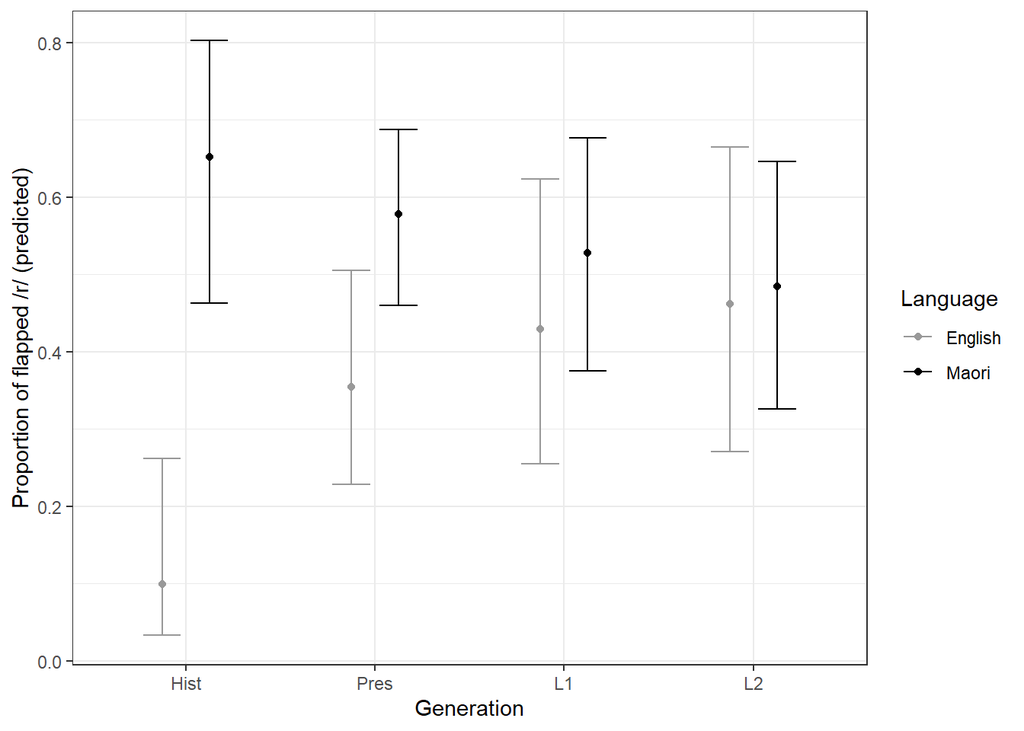

Figure 4.1: Predicted flap proportions with 95% confidence intervals.

```r
mod_effects <- effect(
  term='generation:participant_language',
  mod=Flapmodel2
)

to_plot <- as_tibble(mod_effects)

to_plot |>
  ggplot(
    aes(
      x = generation,
      y = fit,
      colour = participant_language
    )
  ) +
  # add points
  # 'position_dodge' separates the two languages on the plot.
  # If you increase the width, the points get further apart.
  # If you change the value, change it in the code for the error bars
  # below as well.
  geom_point(position = position_dodge(width=0.5)) +
  # add errorbars
  geom_errorbar(
    aes(
      ymin = lower,
      ymax = upper
    ),
    position = position_dodge(width=0.5),
    width = 0.4 # width of error bars.
  ) +
  labs(
    y = "Proportion of flapped /r/ (predicted)",
    x = "Generation",
    colour = "Language"
  ) +
  theme_bw() +
  scale_colour_grey(start = 0.6, end = 0)
```

Figure 4.1 provides a much clearer indication of what is going on in this model. There is a large difference in flap proportion when speaking English and when speaking Māori. This difference seems reduced in the present day kaumātua, and is not present at all in the contemporary L1 and L2 speakers.

We generate p-values for these contrasts using the `emmeans` package.

```r
model.emm <- emmeans(Flapmodel2, specs = ~ generation * participant_language)
contrast(model.emm, "pairwise", simple = "participant_language")
```

```
## generation = Hist:
##  contrast        estimate    SE  df z.ratio p.value
##  English - Maori  -2.8346 0.680 Inf  -4.166  <.0001
##
## generation = Pres:
##  contrast        estimate    SE  df z.ratio p.value
##  English - Maori  -0.9138 0.365 Inf  -2.506  0.0122
##
## generation = L1:
##  contrast        estimate    SE  df z.ratio p.value
##  English - Maori  -0.3960 0.465 Inf  -0.851  0.3947
##
## generation = L2:
##  contrast        estimate    SE  df z.ratio p.value
##  English - Maori  -0.0901 0.496 Inf  -0.182  0.8558
##
## Results are given on the log odds ratio (not the response) scale.
```

These p-values match our visual judgement, where the historical and present day generations have p-values less than 0.05 for the contrast between English and Māori.

As a final check, to ensure we have the right model, we use the `anova` function.

```r
anova(Flapmodel0, Flapmodel1, Flapmodel2)
```

|  | npar | AIC | BIC | logLik | deviance | Chisq | Df | Pr(>Chisq) |
| --- | --- | --- | --- | --- | --- | --- | --- | --- |
| Flapmodel2 | 11 | 1075.540 | 1127.568 | -526.7699 | 1053.540 | NA | NA | NA |
| Flapmodel1 | 16 | 1080.795 | 1156.472 | -524.3976 | 1048.795 | 4.744538 | 5 | 0.4478457 |
| Flapmodel0 | 19 | 1083.979 | 1173.845 | -522.9893 | 1045.979 | 2.816714 | 3 | 0.4207559 |

The results above indicate that our final model is the best of the models considered.

## 4.2 With Tūhoe speakers

Since gender is not significant, we add the Tūhoe data back into the model.

```r
Flapmodel2Tūhoe <- glmer(
  # Dependent variable
  Flap ~
    # Independent variables / Main effects
    generation * participant_language +
    # Random effects
    (1 + participant_language|CleanSpeaker),
  # Family binomial because it's a 'yes or no' modelling problem.
  family = "binomial",
  # Tell it the dataset.
  data = merged_data,
  # Some magic words to give the model additional time to 'congerge'.
  glmerControl(optimizer = "nlminbwrap", optCtrl = list(maxfun = 1e7))
)
```

```r
summary(Flapmodel2Tūhoe)
```

```
## Generalized linear mixed model fit by maximum likelihood (Laplace
##   Approximation) [glmerMod]
##  Family: binomial  ( logit )
## Formula:
## Flap ~ generation * participant_language + (1 + participant_language |
##     CleanSpeaker)
##    Data: merged_data
## Control: glmerControl(optimizer = "nlminbwrap", optCtrl = list(maxfun = 1e+07))
##
##      AIC      BIC   logLik deviance df.resid
##   1190.7   1253.5   -582.3   1164.7      913
##
## Scaled residuals:
##     Min      1Q  Median      3Q     Max
## -2.0048 -0.8335 -0.2958  0.8093  3.6237
##
## Random effects:
##  Groups       Name                      Variance Std.Dev. Corr
##  CleanSpeaker (Intercept)               1.100    1.049
##               participant_languageMaori 1.212    1.101    -0.77
## Number of obs: 926, groups:  CleanSpeaker, 57
##
## Fixed effects:
##                                          Estimate Std. Error z value Pr(>|z|)
## (Intercept)                               -2.1847     0.5743  -3.804 0.000142
## generationTK                               1.9256     0.8091   2.380 0.017316
## generationPres                             1.5943     0.6470   2.464 0.013735
## generationL1                               1.9052     0.6925   2.751 0.005937
## generationL2                               2.0338     0.7066   2.878 0.003997
## participant_languageMaori                  2.8054     0.6593   4.255 2.09e-05
## generationTK:participant_languageMaori    -3.8270     0.9626  -3.976 7.02e-05
## generationPres:participant_languageMaori  -1.9065     0.7457  -2.557 0.010568
## generationL1:participant_languageMaori    -2.4135     0.8000  -3.017 0.002554
## generationL2:participant_languageMaori    -2.7143     0.8171  -3.322 0.000894
##
## (Intercept)                              ***
## generationTK                             *
## generationPres                           *
## generationL1                             **
## generationL2                             **
## participant_languageMaori                ***
## generationTK:participant_languageMaori   ***
## generationPres:participant_languageMaori *
## generationL1:participant_languageMaori   **
## generationL2:participant_languageMaori   ***
## ---
## Signif. codes:  0 '***' 0.001 '**' 0.01 '*' 0.05 '.' 0.1 ' ' 1
##
## Correlation of Fixed Effects:
##             (Intr) gnrtTK gnrtnP gnrtL1 gnrtL2 prtc_M gTK:_M gnP:_M gL1:_M
## generatinTK -0.707
## generatnPrs -0.881  0.625
## generatinL1 -0.826  0.585  0.730
## generatinL2 -0.812  0.574  0.716  0.671
## prtcpnt_lnM -0.817  0.578  0.719  0.675  0.663
## gnrtnTK:p_M  0.558 -0.760 -0.492 -0.462 -0.453 -0.684
## gnrtnPrs:_M  0.717 -0.508 -0.803 -0.594 -0.582 -0.879  0.602
## gnrtnL1:p_M  0.670 -0.475 -0.592 -0.795 -0.544 -0.822  0.563  0.724
## gnrtnL2:p_M  0.658 -0.466 -0.580 -0.544 -0.793 -0.806  0.552  0.709  0.663
```

All terms again come out as significant. But is there a significant difference for Tūhoe of language? We again plot and use `emmeans`.

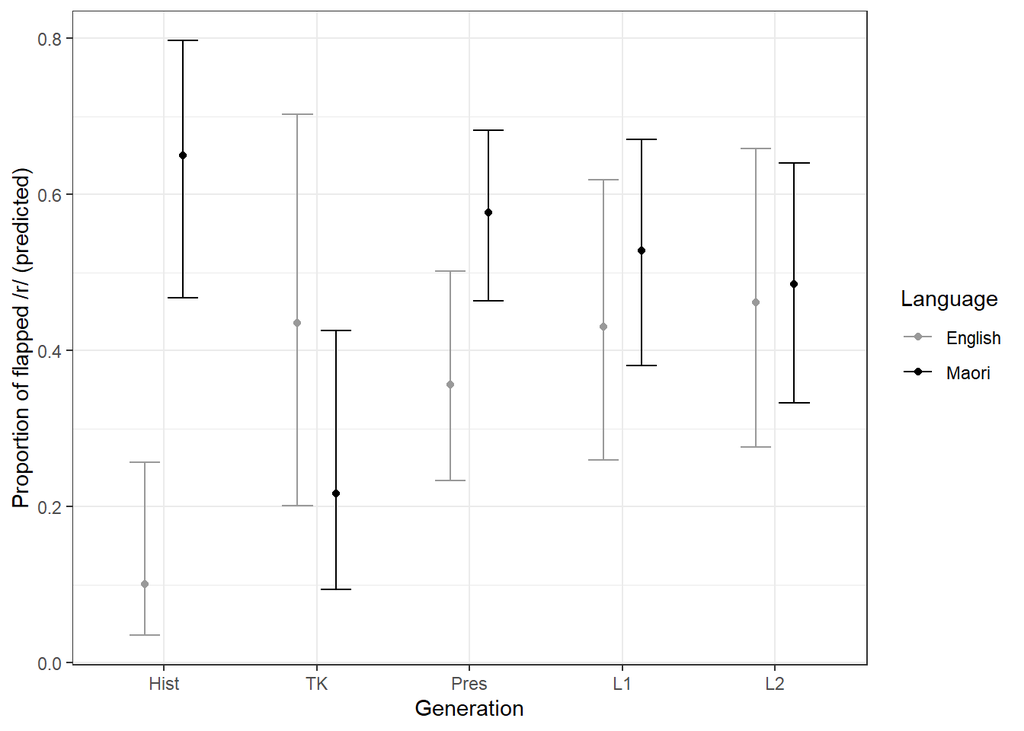

Figure 4.2: Model predictions for flap variable with Tūhoe data added.

```r
mod_effects <- effect(
  term='generation:participant_language',
  mod=Flapmodel2Tūhoe
)

to_plot <- as_tibble(mod_effects)

to_plot |>
  ggplot(
    aes(
      x = generation,
      y = fit,
      colour = participant_language
    )
  ) +
  # add points
  # 'position_dodge' separates the two languages on the plot.
  # If you increase the width, the points get further apart.
  # If you change the value, change it in the code for the error bars
  # below as well.
  geom_point(position = position_dodge(width=0.5)) +
  # add errorbars
  geom_errorbar(
    aes(
      ymin = lower,
      ymax = upper
    ),
    position = position_dodge(width=0.5),
    width = 0.4 # width of error bars.
  ) +
  labs(
    y = "Proportion of flapped /r/ (predicted)",
    x = "Generation",
    colour = "Language"
  ) +
  theme_bw()  +
  scale_colour_grey(start = 0.6, end = 0)
```

Figure 4.2 suggests that there is no significant effect of language for the Tūhoe speakers.

We again use `emmeans`

```r
model.emm <- emmeans(Flapmodel2Tūhoe, specs = ~ generation * participant_language)
contrast(model.emm, "pairwise", by = "generation")
```

```
## generation = Hist:
##  contrast        estimate    SE  df z.ratio p.value
##  English - Maori   -2.805 0.659 Inf  -4.255  <.0001
##
## generation = TK:
##  contrast        estimate    SE  df z.ratio p.value
##  English - Maori    1.022 0.702 Inf   1.455  0.1458
##
## generation = Pres:
##  contrast        estimate    SE  df z.ratio p.value
##  English - Maori   -0.899 0.356 Inf  -2.527  0.0115
##
## generation = L1:
##  contrast        estimate    SE  df z.ratio p.value
##  English - Maori   -0.392 0.456 Inf  -0.860  0.3900
##
## generation = L2:
##  contrast        estimate    SE  df z.ratio p.value
##  English - Maori   -0.091 0.484 Inf  -0.188  0.8507
##
## Results are given on the log odds ratio (not the response) scale.
```

Our visual judgement of no significant effect of language for Tūhoe speakers is confirmed by the p-value above (0.1458).

# 5 Binary diphthong analysis

We now apply the same approach to the binary diphthong variable.

```r
Dmodel0 <- glmer(
  # Dependent variable
  diphthong ~
    # Independent variables / Main effects
    generation * participant_gender * participant_language +
    # Random effects
    (1 + participant_language|CleanSpeaker),
  # Family binomial because it's a 'yes or no' modelling problem.
  family = "binomial",
  # Tell it the dataset.
  data = filtered_data,
  # Some magic words to give the model additional time to 'converge'.
  glmerControl(optimizer = "nlminbwrap", optCtrl = list(maxfun = 1e7)),
  # Optimizer chosen using 'AllFit' - most don't fit as we're at the limits of
  # what we can fit with these data.
)
```

Let’s have a look at the summary.

```r
summary(Dmodel0)
```

```
## Generalized linear mixed model fit by maximum likelihood (Laplace
##   Approximation) [glmerMod]
##  Family: binomial  ( logit )
## Formula: diphthong ~ generation * participant_gender * participant_language +
##     (1 + participant_language | CleanSpeaker)
##    Data: filtered_data
## Control: glmerControl(optimizer = "nlminbwrap", optCtrl = list(maxfun = 1e+07))
##
##      AIC      BIC   logLik deviance df.resid
##    728.7    818.6   -345.4    690.7      818
##
## Scaled residuals:
##     Min      1Q  Median      3Q     Max
## -4.5930  0.2653  0.3410  0.4460  0.9142
##
## Random effects:
##  Groups       Name                      Variance Std.Dev. Corr
##  CleanSpeaker (Intercept)               0.3802   0.6166
##               participant_languageMaori 0.1205   0.3472   -0.76
## Number of obs: 837, groups:  CleanSpeaker, 52
##
## Fixed effects:
##                                                              Estimate
## (Intercept)                                                   3.11193
## generationPres                                               -0.97015
## generationL1                                                 -1.09903
## generationL2                                                 -1.71940
## participant_genderM                                          -1.54261
## participant_languageMaori                                    -0.64452
## generationPres:participant_genderM                            0.32360
## generationL1:participant_genderM                              1.88594
## generationL2:participant_genderM                              1.69425
## generationPres:participant_languageMaori                      0.83246
## generationL1:participant_languageMaori                        0.05568
## generationL2:participant_languageMaori                        0.02486
## participant_genderM:participant_languageMaori                 2.29876
## generationPres:participant_genderM:participant_languageMaori -1.45398
## generationL1:participant_genderM:participant_languageMaori   -1.45370
## generationL2:participant_genderM:participant_languageMaori   -1.69377
##                                                              Std. Error z value
```

[output cut: 20 more lines]

```
## generationL2                                                  0.14189
## participant_genderM                                           0.19896
## participant_languageMaori                                     0.59434
## generationPres:participant_genderM                            0.80505
## generationL1:participant_genderM                              0.18387
## generationL2:participant_genderM                              0.21707
## generationPres:participant_languageMaori                      0.52709
## generationL1:participant_languageMaori                        0.96674
## generationL2:participant_languageMaori                        0.98489
## participant_genderM:participant_languageMaori                 0.16612
## generationPres:participant_genderM:participant_languageMaori  0.41822
## generationL1:participant_genderM:participant_languageMaori    0.44963
## generationL2:participant_genderM:participant_languageMaori    0.35458
## ---
## Signif. codes:  0 '***' 0.001 '**' 0.01 '*' 0.05 '.' 0.1 ' ' 1
```

No terms appear as significant, so we leave this variable behind.

# 6 Diphthong ratio model

We now backfit using the diphthong ratio variable. This time we use a linear model, as the data is continuous.

```r
Rmodel0 <- lmer(
  # Dependent variable
  Ratio ~
    # Independent variables / Main effects
    generation * participant_gender * participant_language +
    # Random effects
    (1 + participant_language|CleanSpeaker),
  # Tell it the dataset.
  data = filtered_data,
  # Some magic words to give the model additional time to 'converge'.
  ## lmerControl(optimizer = "nlminbwrap", optCtrl = list(maxfun = 1e7)),
  # Optimizer chosen using 'AllFit' - most don't fit as we're at the limits of
  # what we can fit with these data.
)
```

```r
summary(Rmodel0)
```

```
## Linear mixed model fit by REML ['lmerMod']
## Formula: Ratio ~ generation * participant_gender * participant_language +
##     (1 + participant_language | CleanSpeaker)
##    Data: filtered_data
##
## REML criterion at convergence: -1174.4
##
## Scaled residuals:
##     Min      1Q  Median      3Q     Max
## -2.5992 -0.7104 -0.0584  0.6409  3.7183
##
## Random effects:
##  Groups       Name                      Variance Std.Dev. Corr
##  CleanSpeaker (Intercept)               0.001022 0.03196
##               participant_languageMaori 0.001646 0.04057  -0.80
##  Residual                               0.009223 0.09604
## Number of obs: 704, groups:  CleanSpeaker, 52
##
## Fixed effects:
##                                                              Estimate
## (Intercept)                                                   0.54979
## generationPres                                               -0.10732
## generationL1                                                 -0.01383
## generationL2                                                 -0.04704
## participant_genderM                                          -0.08918
## participant_languageMaori                                    -0.08160
## generationPres:participant_genderM                            0.15972
## generationL1:participant_genderM                              0.07855
## generationL2:participant_genderM                              0.05709
## generationPres:participant_languageMaori                      0.16247
## generationL1:participant_languageMaori                        0.06909
## generationL2:participant_languageMaori                        0.11048
## participant_genderM:participant_languageMaori                 0.20200
## generationPres:participant_genderM:participant_languageMaori -0.28402
## generationL1:participant_genderM:participant_languageMaori   -0.22341
## generationL2:participant_genderM:participant_languageMaori   -0.16412
##                                                              Std. Error t value
## (Intercept)                                                     0.02689  20.443
## generationPres                                                  0.03094  -3.468
## generationL1                                                    0.03375  -0.410
## generationL2                                                    0.03452  -1.363
## participant_genderM                                             0.03595  -2.481
## participant_languageMaori                                       0.03375  -2.418
## generationPres:participant_genderM                              0.04279   3.733
## generationL1:participant_genderM                                0.04598   1.708
## generationL2:participant_genderM                                0.04712   1.212
## generationPres:participant_languageMaori                        0.03951   4.112
## generationL1:participant_languageMaori                          0.04303   1.606
## generationL2:participant_languageMaori                          0.04504   2.453
## participant_genderM:participant_languageMaori                   0.04821   4.190
## generationPres:participant_genderM:participant_languageMaori    0.05687  -4.994
## generationL1:participant_genderM:participant_languageMaori      0.06175  -3.618
## generationL2:participant_genderM:participant_languageMaori      0.06374  -2.575
```

These linear models do not give p-values. We use t-values great than 2 as a rough heuristic for keeping terms in our model. In this case, each term has at least one ‘significant’ coefficient.

We check the residuals of the model to ensure that they are evenly distributed around 0:

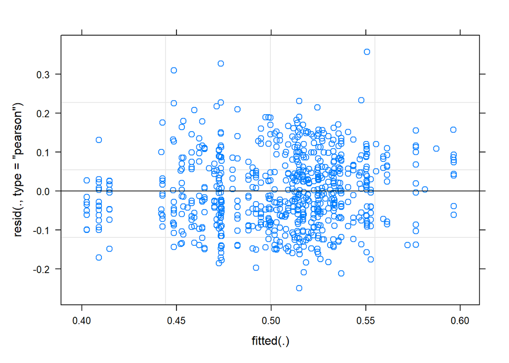

```r
plot(Rmodel0)
```

And check the qq plot:

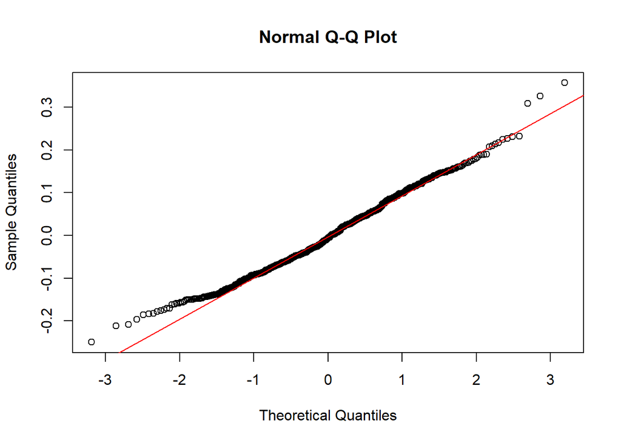

```r
qqnorm(residuals(Rmodel0))
qqline(residuals(Rmodel0), datax = FALSE, distribution = qnorm,
       probs = c(0.25, 0.75), qtype = 7, col="red")
```

Both look OK!

We plot contrasts:

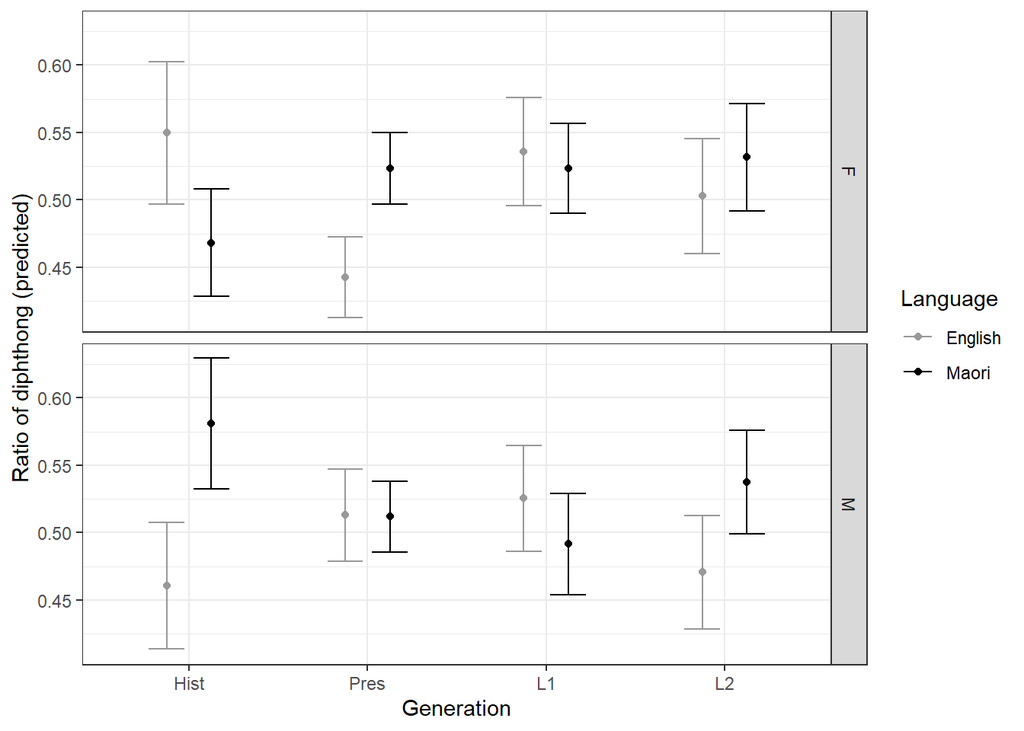

```r
mod_effects <- effect(
  term='generation:participant_gender:participant_language',
  mod=Rmodel0
)

to_plot <- as_tibble(mod_effects)

to_plot |>
  ggplot(
    aes(
      x = generation,
      y = fit,
      colour = participant_language
    )
  ) +
  # add points
  geom_point(position = position_dodge(width=0.5)) +
  # add errorbars
  geom_errorbar(
    aes(
      ymin = lower,
      ymax = upper
    ),
    position = position_dodge(width=0.5),
    width = 0.4 # width of error bars.
  ) +
  labs(
    # title = "Title Goes Here",
    # subtitle = "Subtitle if you want it",
    y = "Ratio of diphthong (predicted)",
    x = "Generation",
    colour = "Language"
  ) +
  theme_bw()  +
  scale_colour_grey(start = 0.6, end = 0) +
  # split by gender
  facet_grid(rows = vars(participant_gender))
```

This is a complicated story!

```r
model.emm <- emmeans(Rmodel0, specs = ~ generation * participant_gender * participant_language)
contrast(model.emm, "consec", simple="each",  adjust="bonferroni")
```

```
## $`simple contrasts for generation`
## participant_gender = F, participant_language = English:
##  contrast     estimate     SE   df t.ratio p.value
##  Pres - Hist -0.107315 0.0312 48.9  -3.437  0.0036
##  L1 - Pres    0.093489 0.0256 36.4   3.653  0.0024
##  L2 - L1     -0.033216 0.0298 37.1  -1.114  0.8173
##
## participant_gender = M, participant_language = English:
##  contrast     estimate     SE   df t.ratio p.value
##  Pres - Hist  0.052409 0.0299 41.2   1.752  0.2618
##  L1 - Pres    0.012314 0.0268 33.9   0.460  1.0000
##  L2 - L1     -0.054681 0.0294 31.9  -1.858  0.2175
##
## participant_gender = F, participant_language = Maori:
##  contrast     estimate     SE   df t.ratio p.value
##  Pres - Hist  0.055158 0.0244 38.7   2.257  0.0892
##  L1 - Pres    0.000108 0.0218 36.8   0.005  1.0000
##  L2 - L1      0.008169 0.0266 41.9   0.307  1.0000
##
## participant_gender = M, participant_language = Maori:
##  contrast     estimate     SE   df t.ratio p.value
##  Pres - Hist -0.069134 0.0284 53.5  -2.434  0.0550
##  L1 - Pres   -0.020460 0.0234 33.5  -0.873  1.0000
##  L2 - L1      0.045990 0.0274 35.6   1.676  0.3075
##
## Degrees-of-freedom method: kenward-roger
## P value adjustment: bonferroni method for 3 tests
##
## $`simple contrasts for participant_gender`
## generation = Hist, participant_language = English:
##  contrast estimate     SE   df t.ratio p.value
##  M - F    -0.08918 0.0364 47.8  -2.451  0.0180
##
## generation = Pres, participant_language = English:
##  contrast estimate     SE   df t.ratio p.value
##  M - F     0.07055 0.0234 39.1   3.019  0.0044
##
## generation = L1, participant_language = English:
##  contrast estimate     SE   df t.ratio p.value
##  M - F    -0.01063 0.0287 32.7  -0.370  0.7138
```

[output cut: 42 more lines]

```
##  Maori - English  0.12040 0.0349 61.0   3.452  0.0010
##
## generation = Pres, participant_gender = M:
##  contrast        estimate     SE   df t.ratio p.value
##  Maori - English -0.00114 0.0223 44.9  -0.051  0.9593
##
## generation = L1, participant_gender = M:
##  contrast        estimate     SE   df t.ratio p.value
##  Maori - English -0.03392 0.0279 30.4  -1.214  0.2341
##
## generation = L2, participant_gender = M:
##  contrast        estimate     SE   df t.ratio p.value
##  Maori - English  0.06675 0.0292 37.1   2.285  0.0281
##
## Degrees-of-freedom method: kenward-roger
```

In most cases with a significant language effect, there is an increase in the relative length of /a:/. The exception to this is the historical female speakers, who seem to reduce the relative length of /a:/ while speaking te reo Māori. These results are discussed further in the paper.